# French Tragedies Dataset

Data Source: https://www.kaggle.com/sharkcpn/french-tragedies The dataset contains 59 text documents in French Language.

## Objective:

estimate the sentiment in these documents  
i.e calculate if individual documents are of positive or negative sentiment  
additionaly classify them into further categories of sentiments

```python
# Load all Libraries

import os
import sqlite3
import numpy as np
import pandas as pd
import matplotlib.pyplot as plt
from tqdm import tqdm
import seaborn as sns
import spacy
import re
from itertools import islice

sns.set_style('whitegrid')

# load with french language model
nlp = spacy.load('fr_core_news_md')
```

# FEEL Lexicon

French Expanded Emotion Lexicon (FEEL)

FEEL is a French lexicon containing more than 14 000 distinct words expressing emotions and sentiments. It follows the Ekman basic two polarities and six emotions (Ekman, 1992). It has been created by automatically translating and expanding the English Emotional Lexicon NRC-Canada (Mohammad & Turney, 2013). The process has been supervised and validated manually by a human professional translator.

Link: http://advanse.lirmm.fr/feel.php

```python
# Load the feel lexicon
lexicon = pd.read_csv('FEEL.csv', delimiter=';', index_col=0)
lexicon.head()
```

| id | word | polarity | joy | fear | sadness | anger | surprise | disgust |
| --- | --- | --- | --- | --- | --- | --- | --- | --- |
| 1 | à ce endroit là | positive | 0 | 0 | 0 | 0 | 0 | 0 |
| 2 | à le hâte | negative | 0 | 1 | 0 | 0 | 1 | 0 |
| 3 | à part | negative | 0 | 0 | 1 | 0 | 0 | 0 |
| 4 | à pic | negative | 0 | 1 | 0 | 0 | 0 | 0 |
| 5 | à rallonge | negative | 0 | 0 | 1 | 0 | 0 | 0 |

```python
print('Shape of feel lexicon df:', lexicon.shape)
```

```
Shape of feel lexicon df: (14127, 8)
```

```python
# Basic statistic
lexicon.describe()
```

|  | joy | fear | sadness | anger | surprise | disgust |
| --- | --- | --- | --- | --- | --- | --- |
| count | 14127.000000 | 14127.000000 | 14127.000000 | 14127.000000 | 14127.000000 | 14127.000000 |
| mean | 0.036880 | 0.226446 | 0.177816 | 0.148864 | 0.083670 | 0.142493 |
| std | 0.188473 | 0.418546 | 0.382371 | 0.355967 | 0.276901 | 0.349568 |
| min | 0.000000 | 0.000000 | 0.000000 | 0.000000 | 0.000000 | 0.000000 |
| 25% | 0.000000 | 0.000000 | 0.000000 | 0.000000 | 0.000000 | 0.000000 |
| 50% | 0.000000 | 0.000000 | 0.000000 | 0.000000 | 0.000000 | 0.000000 |
| 75% | 0.000000 | 0.000000 | 0.000000 | 0.000000 | 0.000000 | 0.000000 |
| max | 1.000000 | 1.000000 | 1.000000 | 1.000000 | 1.000000 | 1.000000 |

```python
# Number of uniques in each column
lexicon.nunique()
```

```
word        14126
polarity        2
joy             2
fear            2
sadness         2
anger           2
surprise        2
disgust         2
dtype: int64
```

all the columns seems to be binary features with value 0 and 1

strangely the 'word' column has one less than the total number of rows.  
i.e there is a duplicate value in word column

```python
# Top 10 words with highest value counts
lexicon.word.value_counts().head(10)
```

```
bien              2
algébrique        1
coincer           1
aristocratique    1
point de vue      1
proportionner     1
glapir            1
midi              1
se procurer       1
siéger            1
Name: word, dtype: int64
```

'bien' is the duplicate

Lets look at those rows

```python
lexicon[lexicon.word == 'bien']
```

| id | word | polarity | joy | fear | sadness | anger | surprise | disgust |
| --- | --- | --- | --- | --- | --- | --- | --- | --- |
| 147 | bien | positive | 1 | 0 | 0 | 0 | 0 | 0 |
| 2831 | bien | positive | 0 | 1 | 0 | 0 | 1 | 0 |

according to [google translate](https://translate.google.co.in/#fr/en/bien) the word `bien` means `good`

the word with id `147` seems ok, but  
the other one seems to be a mistake as it is relating it with `fear` and `surprise`

```python
# remove row with id `2831`
lexicon = lexicon.drop(2831)
```

### Analyse Features in FEEl Lexicon

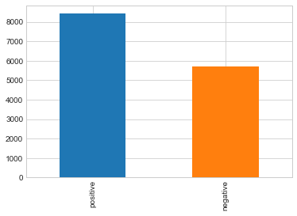

```python
lexicon.polarity.value_counts().plot('bar');
```

Most of the words in the lexicon dictionary are labeled as postive sentiment

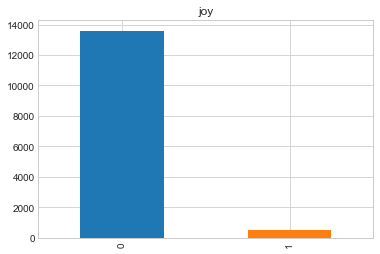

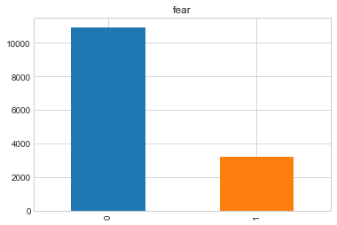

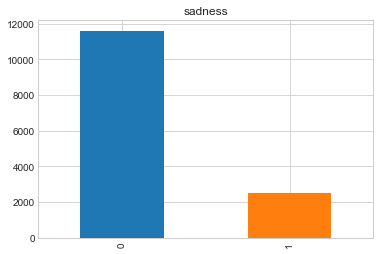

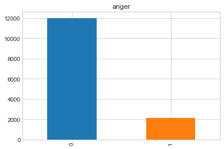

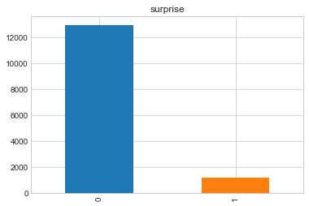

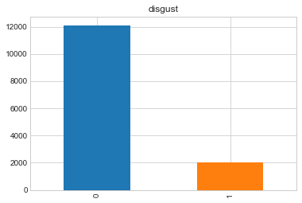

```python
# Plot the distribution of all the emotions in FEEL lexicon
for col in lexicon.columns[2:]:
    lexicon[col].value_counts().plot('bar', title=col)
    plt.show();
```

### Analyse words

```python
lexicon.word.head(10)
```

```
id
1     à ce endroit là
2           à le hâte
3              à part
4               à pic
5          à rallonge
6          abasourdir
7            ablation
8          abominable
9              abrupt
10             absent
Name: word, dtype: object
```

The words in our lexicon does on not only consists of single words but phrases of words

And the words are also not clean as it contains stopwords like `le`, `à`, `là` etc.

```python
# Length of words
word_length = lexicon.word.str.split().apply(lambda lst: len(lst))

# numbers of words grouped by length
word_length.value_counts()
```

```
1    11978
2     1306
3      657
4      141
5       29
6       15
Name: word, dtype: int64
```

Most of the words are of length one.  
The length of some of the words are as big as 6

```python
# Set `word` column as index for easy lookup
lexicon = lexicon.set_index('word')
lexicon.head()
```

| word | polarity | joy | fear | sadness | anger | surprise | disgust |
| --- | --- | --- | --- | --- | --- | --- | --- |
| à ce endroit là | positive | 0 | 0 | 0 | 0 | 0 | 0 |
| à le hâte | negative | 0 | 1 | 0 | 0 | 1 | 0 |
| à part | negative | 0 | 0 | 1 | 0 | 0 | 0 |
| à pic | negative | 0 | 1 | 0 | 0 | 0 | 0 |
| à rallonge | negative | 0 | 0 | 1 | 0 | 0 | 0 |

# Load French Tragedies Data

```python
# Save all the text to sqlite database of easy access later

files = os.listdir('dataset/')

with sqlite3.connect('french_tragedies.db') as conn:
    curr = conn.cursor()
    curr.execute('DROP TABLE IF EXISTS French_tragedies;')
    curr.execute('CREATE TABLE French_tragedies(Filename text NOT NULL, Text text);')
    for filename in tqdm(files):
        with open('dataset/'+ filename, encoding='utf-8') as file:
            text = file.read().replace('\n', '')
            curr.execute('insert into French_tragedies(Filename, Text) values (?, ?);', (filename, text))
```

```python
# Load as pandas dataframe
with sqlite3.connect('french_tragedies.db') as conn:
    french_data = pd.read_sql_query('Select * from French_tragedies', conn)
```

```python
french_data.head(10)
```

|  | Filename | Text |
| --- | --- | --- |
| 0 | Crebillon_TR-V-1703-Idomenee.txt | IDOMÉNÉE, TRAGÉDIE. CRÉBILL... |
| 1 | Crebillon_TR-V-1707-Atree.txt | ATRÉE et THYESTE, TRAGÉDIE. ... |
| 2 | Crebillon_TR-V-1708-Electre.txt | ÉLECTRE, TRAGÉDIE CRÉBILLON... |
| 3 | Crebillon_TR-V-1711-Rhadamisthe.txt | RHADAMISTHE et ZÉNOBIE, TRAGÉDIE ... |
| 4 | Crebillon_TR-V-1717-Semiramis.txt | SÉMIRAMIS, TRAGÉDIE CRÉBILL... |
| 5 | Crebillon_TR-V-1726-Pyrrhus.txt | PYRRHUS, TRAGÉDIE CRÉBILLON... |
| 6 | Crebillon_TR-V-1749-Catilina.txt | CATILINA, TRAGÉDIE CRÉBILLO... |
| 7 | Crebillon_TR-V-1749-Xerces.txt | XERCÈS, TRAGÉDIE CRÉBILLON,... |
| 8 | Crebillon_TR-V-1754-Triumvirat.txt | LE TRIUMVIRAT ou LA MORT DE CICÉRON, TRAGÉDIE ... |
| 9 | PCorneille_TR-V-1639-Medee.txt | MÉDÉE, TRAGÉDIE CORNEILLE, ... |

# Approach 1

For a given text document count the find the words that are in our lexicon and count their polarity and emotions.

Since our lexicon dictionary has words of length 1 to 6. We will try to look for all of them

```python
# https://stackoverflow.com/a/6822773
def window(seq, n=2):
    '''
    Returns a sliding window (of width n) over data from the iterable
       s -> (s0,s1,...s[n-1]), (s1,s2,...,sn), ...
    '''
    it = iter(seq)
    result = tuple(islice(it, n))
    if len(result) == n:
        yield result
    for elem in it:
        result = result[1:] + (elem,)
        yield result


def get_sentiment(sent):
    '''
    yields the sentiments of words found in lexicon
    for each window of length 1 to 6 in sent
    '''
    for window_size in range(6, 0, -1):
        # search all the words of length window_size
        for each in window(sent.split(), window_size):
            sub_str = ' '.join(each)
            try:
                sentiment = lexicon.loc[sub_str]

                # remove that phrase so that we don't see it again for smaller window
                sent.replace(sub_str, '')

                yield sentiment
            except KeyError:
                # if phrase not in lexicon ignore and continue
                pass

def gen_sentiments(text):
    '''
    Returns a pandas series containing sentiment count of the text
    '''
    # remove redundant white spaces
    text = ' '.join(text.split())

    # Split the text on punctuations to get sentences
    sents = re.split(r'[,?!\.;:]', text)

    # Sentiment features to count
    features = {
        'polarity_diff': 0, # diff. of positive and negative polarity
        'joy':0,
        'fear': 0,
        'sadness': 0,
        'anger': 0,
        'surprise': 0,
        'disgust': 0
    }
    for sent in sents:
        for sentiment in get_sentiment(sent):
            if sentiment['polarity'] == 'positive':
                features['polarity_diff'] += 1
            else:
                # if the word is negative reduce the overall polarity
                features['polarity_diff'] -= 1
            features['joy'] += sentiment['joy']
            features['fear'] += sentiment['fear']
            features['sadness'] += sentiment['sadness']
            features['anger'] += sentiment['anger']
            features['surprise'] += sentiment['surprise']
            features['disgust'] += sentiment['disgust']

    return pd.Series(features)
```

```python
sentiment_features = french_data['Text'].apply(gen_sentiments)
```

```python
sentiment_features.head(15)
```

|  | anger | disgust | fear | joy | polarity_diff | sadness | surprise |
| --- | --- | --- | --- | --- | --- | --- | --- |
| 0 | 694 | 589 | 805 | 108 | 172 | 771 | 216 |
| 1 | 581 | 555 | 694 | 130 | 416 | 648 | 225 |
| 2 | 571 | 532 | 795 | 149 | 354 | 743 | 218 |
| 3 | 572 | 466 | 623 | 107 | 366 | 568 | 200 |
| 4 | 520 | 435 | 667 | 154 | 570 | 611 | 247 |
| 5 | 589 | 525 | 712 | 173 | 522 | 720 | 234 |
| 6 | 636 | 545 | 732 | 145 | 573 | 647 | 242 |
| 7 | 622 | 543 | 763 | 156 | 619 | 752 | 238 |
| 8 | 518 | 498 | 637 | 150 | 593 | 616 | 216 |
| 9 | 543 | 485 | 629 | 159 | 642 | 640 | 213 |
| 10 | 456 | 457 | 523 | 161 | 1304 | 489 | 212 |
| 11 | 505 | 452 | 647 | 205 | 720 | 683 | 192 |
| 12 | 537 | 536 | 642 | 163 | 676 | 648 | 210 |
| 13 | 473 | 491 | 630 | 195 | 783 | 619 | 228 |
| 14 | 483 | 541 | 583 | 162 | 854 | 563 | 250 |

```python
sentiment_features.describe()
```

|  | anger | disgust | fear | joy | polarity_diff | sadness | surprise |
| --- | --- | --- | --- | --- | --- | --- | --- |
| count | 59.000000 | 59.000000 | 59.000000 | 59.000000 | 59.000000 | 59.000000 | 59.000000 |
| mean | 474.762712 | 451.423729 | 595.627119 | 144.355932 | 656.813559 | 565.423729 | 201.847458 |
| std | 93.507576 | 80.404195 | 112.344283 | 36.262340 | 249.181244 | 109.550524 | 39.354627 |
| min | 273.000000 | 230.000000 | 331.000000 | 66.000000 | 172.000000 | 298.000000 | 100.000000 |
| 25% | 418.000000 | 407.500000 | 530.000000 | 116.000000 | 501.000000 | 492.000000 | 184.500000 |
| 50% | 465.000000 | 457.000000 | 608.000000 | 150.000000 | 605.000000 | 570.000000 | 210.000000 |
| 75% | 542.500000 | 494.500000 | 672.000000 | 167.500000 | 784.500000 | 647.500000 | 226.500000 |
| max | 694.000000 | 628.000000 | 805.000000 | 219.000000 | 1304.000000 | 775.000000 | 269.000000 |

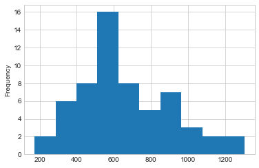

```python
sentiment_features['polarity_diff'].plot('hist');
```

The polarity of all the words are positive ranging from 172 to 1304.

On looking at the text themself, the text with highest polarity_diff was positive and lowest diff was negative

but it it hard to classify the sentiment bases on this without any supervised process

For now lets explore more featurization

# Approach 2 (cleaned text)

Instead of raw text now lets try counting the sentiment and emotion properties on cleaned text data.

We will be using [spacy](https://spacy.io) for tokenizaion, lemmatization, and pos tagging as it has support for french lannguage for npl tasks

```python
def cleaned_sentiment(text):

    doc = nlp(text)
    features = {
        'polarity_diff': 0, # diff. of positive and negative polarity
        'joy':0,
        'fear': 0,
        'sadness': 0,
        'anger': 0,
        'surprise': 0,
        'disgust': 0
    }
    for token in doc:
        # Lemmatize the word
        cleaned_token = token.lemma_
        try:
            sentiment = lexicon.loc[cleaned_token]
            if sentiment['polarity'] == 'positive':
                features['polarity_diff'] += 1
            else:
                # if the word is negative reduce the overall polarity
                features['polarity_diff'] -= 1
            features['joy'] += sentiment['joy']
            features['fear'] += sentiment['fear']
            features['sadness'] += sentiment['sadness']
            features['anger'] += sentiment['anger']
            features['surprise'] += sentiment['surprise']
            features['disgust'] += sentiment['disgust']
        except KeyError:
            pass
    return pd.Series(features)
```

```python
sentiment_features = french_data['Text'].apply(cleaned_sentiment)
```

```python
sentiment_features.head(15)
```

|  | anger | disgust | fear | joy | polarity_diff | sadness | surprise |
| --- | --- | --- | --- | --- | --- | --- | --- |
| 0 | 1083 | 1024 | 1412 | 169 | 566 | 1287 | 410 |
| 1 | 886 | 928 | 1170 | 200 | 1013 | 1017 | 433 |
| 2 | 981 | 975 | 1294 | 227 | 919 | 1208 | 432 |
| 3 | 897 | 851 | 1026 | 150 | 819 | 953 | 356 |
| 4 | 839 | 820 | 1088 | 224 | 1240 | 984 | 478 |
| 5 | 904 | 917 | 1120 | 254 | 1152 | 1100 | 433 |
| 6 | 1032 | 1021 | 1273 | 220 | 1231 | 1116 | 497 |
| 7 | 1020 | 1029 | 1295 | 237 | 1162 | 1198 | 465 |
| 8 | 892 | 955 | 1102 | 226 | 1208 | 1077 | 423 |
| 9 | 967 | 988 | 1214 | 240 | 1134 | 1139 | 436 |
| 10 | 699 | 832 | 990 | 223 | 2095 | 836 | 481 |
| 11 | 907 | 928 | 1196 | 272 | 1434 | 1214 | 462 |
| 12 | 966 | 1041 | 1246 | 230 | 1351 | 1191 | 501 |
| 13 | 878 | 977 | 1251 | 288 | 1385 | 1143 | 501 |
| 14 | 834 | 1054 | 1120 | 234 | 1606 | 980 | 536 |

```python
sentiment_features.describe()
```

|  | anger | disgust | fear | joy | polarity_diff | sadness | surprise |
| --- | --- | --- | --- | --- | --- | --- | --- |
| count | 59.000000 | 59.000000 | 59.000000 | 59.000000 | 59.000000 | 59.000000 | 59.000000 |
| mean | 829.050847 | 884.169492 | 1104.898305 | 212.813559 | 1263.135593 | 1014.152542 | 433.610169 |
| std | 138.509482 | 137.509392 | 174.126262 | 45.586021 | 382.844006 | 167.783298 | 73.796789 |
| min | 486.000000 | 467.000000 | 627.000000 | 97.000000 | 434.000000 | 547.000000 | 212.000000 |
| 25% | 735.500000 | 821.000000 | 1006.000000 | 185.000000 | 1021.000000 | 893.000000 | 408.500000 |
| 50% | 854.000000 | 888.000000 | 1133.000000 | 220.000000 | 1208.000000 | 1048.000000 | 436.000000 |
| 75% | 908.000000 | 976.000000 | 1248.500000 | 237.500000 | 1481.000000 | 1127.500000 | 472.500000 |
| max | 1083.000000 | 1160.000000 | 1412.000000 | 318.000000 | 2103.000000 | 1306.000000 | 601.000000 |

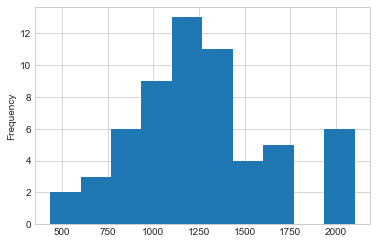

```python
sentiment_features['polarity_diff'].plot('hist');
```

This is somewhat similar to our approach 1  
but the values of `polarity_diff` as even more positive

# Approach 3 (Use only adjectives and adverbs)

Now lets try only considering adjectives and adverbs as these types of words are the most important in classification of sentiment

```python
def cleaned_sentiment(text):
    doc = nlp(text)
    features = {
        'polarity_diff': 0, # diff. of positive and negative polarity
        'joy':0,
        'fear': 0,
        'sadness': 0,
        'anger': 0,
        'surprise': 0,
        'disgust': 0
    }
    for token in doc:
        # consider only those words which are detected
        # as adjective or adverb
        if token.pos_ == 'ADV' or token.pos_ == 'ADJ':
            # taking the lemmatize form
            cleaned_token = token.lemma_
            try:
                sentiment = lexicon.loc[cleaned_token]
                if sentiment['polarity'] == 'positive':
                    features['polarity_diff'] += 1
                else:
                    # if the word is negative reduce the overall polarity
                    features['polarity_diff'] -= 1
                features['joy'] += sentiment['joy']
                features['fear'] += sentiment['fear']
                features['sadness'] += sentiment['sadness']
                features['anger'] += sentiment['anger']
                features['surprise'] += sentiment['surprise']
                features['disgust'] += sentiment['disgust']
            except KeyError:
                pass
    return pd.Series(features)
```

```python
sentiment_features = french_data['Text'].apply(cleaned_sentiment)
```

```python
sentiment_features.head(15)
```

|  | anger | disgust | fear | joy | polarity_diff | sadness | surprise |
| --- | --- | --- | --- | --- | --- | --- | --- |
| 0 | 276 | 246 | 285 | 47 | -212 | 349 | 59 |
| 1 | 186 | 177 | 196 | 50 | -56 | 245 | 45 |
| 2 | 224 | 221 | 243 | 67 | -84 | 288 | 57 |
| 3 | 240 | 218 | 202 | 42 | -114 | 252 | 40 |
| 4 | 208 | 194 | 213 | 55 | -104 | 271 | 52 |
| 5 | 201 | 193 | 219 | 61 | -46 | 279 | 52 |
| 6 | 239 | 218 | 245 | 61 | -66 | 267 | 58 |
| 7 | 286 | 260 | 275 | 82 | -114 | 363 | 66 |
| 8 | 205 | 177 | 234 | 66 | -42 | 270 | 52 |
| 9 | 153 | 138 | 184 | 77 | 85 | 227 | 55 |
| 10 | 116 | 101 | 140 | 105 | 167 | 171 | 58 |
| 11 | 132 | 133 | 169 | 93 | 91 | 224 | 66 |
| 12 | 161 | 140 | 179 | 70 | 81 | 216 | 42 |
| 13 | 149 | 128 | 178 | 96 | 95 | 211 | 57 |
| 14 | 143 | 125 | 157 | 70 | 101 | 193 | 67 |

```python
sentiment_features.describe()
```

|  | anger | disgust | fear | joy | polarity_diff | sadness | surprise |
| --- | --- | --- | --- | --- | --- | --- | --- |
| count | 59.000000 | 59.000000 | 59.000000 | 59.00000 | 59.000000 | 59.000000 | 59.000000 |
| mean | 168.542373 | 154.694915 | 188.423729 | 67.79661 | 11.254237 | 223.694915 | 53.491525 |
| std | 47.213865 | 44.649306 | 44.852710 | 19.99205 | 85.913066 | 49.069358 | 14.285721 |
| min | 97.000000 | 77.000000 | 101.000000 | 32.00000 | -212.000000 | 127.000000 | 23.000000 |
| 25% | 129.500000 | 121.500000 | 158.500000 | 52.00000 | -56.500000 | 185.000000 | 44.000000 |
| 50% | 163.000000 | 148.000000 | 184.000000 | 67.00000 | 8.000000 | 224.000000 | 57.000000 |
| 75% | 201.000000 | 186.000000 | 219.000000 | 82.00000 | 83.000000 | 250.500000 | 61.000000 |
| max | 286.000000 | 260.000000 | 285.000000 | 113.00000 | 175.000000 | 363.000000 | 89.000000 |

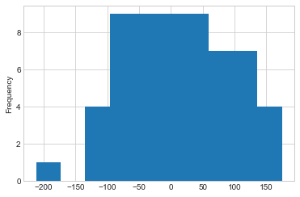

```python
sentiment_features['polarity_diff'].plot('hist');
```

This looks a lot better as it ranges between positive and negative values.  
That means for some documents positive words are more that the nagative sentiment words and vice versa

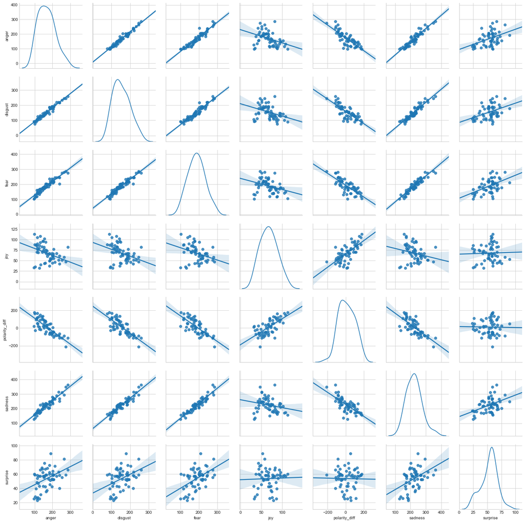

```python
# Pair plots of all our sentiment features
sns.pairplot(sentiment_features, kind="reg", diag_kind="kde");
```

The above pair plot makes a lot of sense  
as we can see

the pairs (disgust, anger) , (fear, anger), (fear, disgust), (sadness, anger), (sadness, disgust), (sadness, fear) are positively correlated and it makes sense.

the emotions anger, disgust, fear and sadness are negatively correlated to positive polarity(polarity_diff)

But surprise emotion looks a bit ambiguous as it does not show good correlation to any of the other correlations

# Document Classification

Since our approach 3 which only uses adjectives and adverbs for counting features looks somewhat promising.

Lets try to classify based on the polarity score stat we obtained.

i.e if `polarity_diff` is positive then the document has positive sentiment else the document has negative sentiment

We can use the emotions to compare it it with other documents as how good it if compared to other documents.  
Example: if the percentile score of joy emotion is 90% then it has more text that represents joy that 90% of the document

```python
# to get the percentile score
from scipy.stats import percentileofscore
```

```python
emotion_labels = ['joy', 'fear', 'sadness', 'anger', 'surprise', 'disgust']

def print_report(index):
    '''
    Prints the polarity and emotion percentile bar graph
    compared to other document
    '''
    print('Document:', french_data.loc[index]['Filename'])
    polarity = 'positive' if sentiment_features.loc[index]['polarity_diff'] > 0 else 'negative'
    print('Polarity:', polarity)
    emotions = {}
    for label in emotion_labels:
        emotions[label] = percentileofscore(sentiment_features[label], sentiment_features.loc[index][label])

    # Sort by values (highest value first)
    emotions = pd.Series(emotions)#.sort_values()
    emotions.plot(kind='barh', xlim=(0, 100));
    plt.show();
```

#### Most Positive Document

```
Document: PCorneille_TR-V-1666-Agesilas.txt
Polarity: positive
```

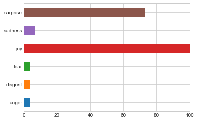

```python
index = sentiment_features['polarity_diff'].idxmax()
print_report(index)
```

The most positive document has highest percentile score for joy

and very low percentile score for sadness, fear, disgust and anger.

and these scores makes a lot of sense for the most positive document

#### Most Negative Document

```
Document: Crebillon_TR-V-1703-Idomenee.txt
Polarity: negative
```

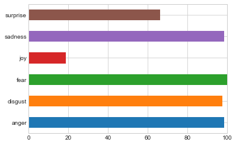

```python
index = sentiment_features['polarity_diff'].idxmin()
print_report(index)
```

The most negative document has a very low joy percentile score

But has high scores for fear, sadness, anger and disgust

and it makes sense for a negative sentiment document

## Sentiment and emotion scores for all the documents

```
Document: Crebillon_TR-V-1703-Idomenee.txt
Polarity: negative
```

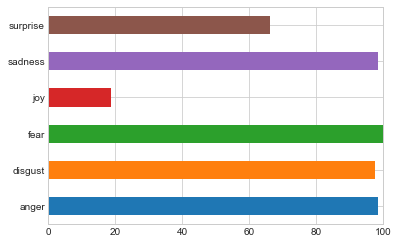

```
============================================================
Document: Crebillon_TR-V-1707-Atree.txt
Polarity: negative
```

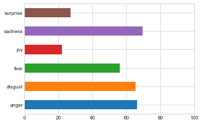

```
============================================================
Document: Crebillon_TR-V-1708-Electre.txt
Polarity: negative
```

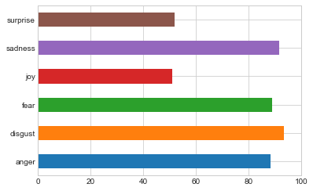

```
============================================================
Document: Crebillon_TR-V-1711-Rhadamisthe.txt
Polarity: negative
```

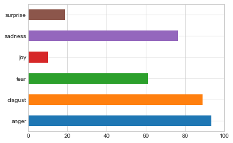

```
============================================================
Document: Crebillon_TR-V-1717-Semiramis.txt
Polarity: negative
```

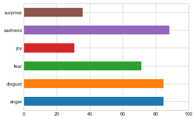

```
============================================================
Document: Crebillon_TR-V-1726-Pyrrhus.txt
Polarity: negative
```

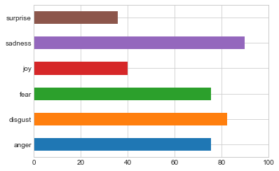

```
============================================================
Document: Crebillon_TR-V-1749-Catilina.txt
Polarity: negative
```

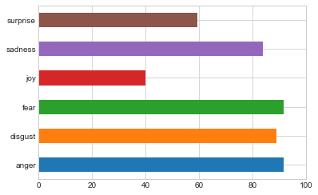

```
============================================================
Document: Crebillon_TR-V-1749-Xerces.txt
Polarity: negative
```

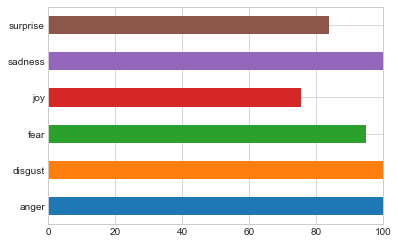

```
============================================================
Document: Crebillon_TR-V-1754-Triumvirat.txt
Polarity: negative
```

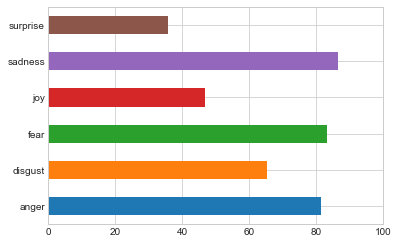

```
============================================================
Document: PCorneille_TR-V-1639-Medee.txt
Polarity: positive
```

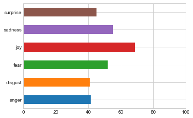

```
============================================================
Document: PCorneille_TR-V-1639-Nicomede.txt
Polarity: positive
```

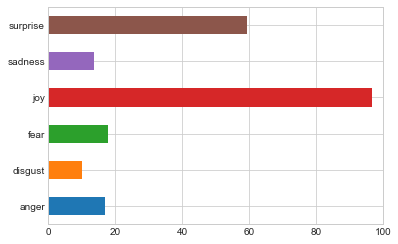

```
============================================================
Document: PCorneille_TR-V-1641-Horace.txt
Polarity: positive
```

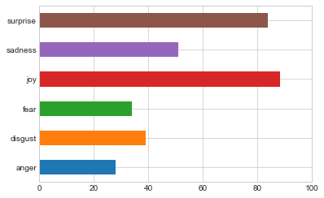

```
============================================================
Document: PCorneille_TR-V-1643-Cinna.txt
Polarity: positive
```

[47 more figures not shown]

```python
for index in range(len(french_data)):
    print_report(index)
    print('='*60)
```

# To Try:

- Standardize the sentiment score and give a soft score rather that just saying positive or negative
- Find a different way of scoring the emotions that takes into account the score of other emotions instead of just doing univariate comparison
- Find bigger and better lexicon dictionary to use
- Try to find and use prebuilt sentiwordnet models
- TextBlob library has a sentiment analyser for french try to compare our score with TextBlob implementation

# References:

- http://www.aclweb.org/anthology/S13-2091
- https://pdfs.semanticscholar.org/0cd7/2a47e568b95d418f95fdc8918414a7cff5f0.pdf
- http://www.aclweb.org/anthology/J11-2001